# Bayesian-Logistic-Modeling-of-Credit-Risk-and-Loan-Approval

BABUSI BRIAN RASENYAI

2026-01-13

```r
library(dplyr)
```

```
##
##    0    1
## 1658  342
```

```
## [1] 0.171
```

```
## # A tibble: 2 × 5
##   Loan_Approved mean_income mean_credit_score mean_loan_amount mean_age
##           <dbl>       <dbl>             <dbl>            <dbl>    <dbl>
## 1             0      81410.              542.           27619.     43.5
## 2             1      99675.              749.           14994.     45.5
```

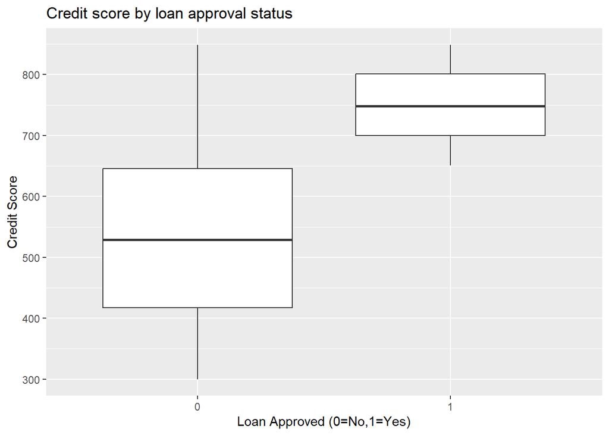

#The stark vertical displacement between the “approved” and “Denied” groups indicates that credit score is not merely a contributing factor, but likely the primary thresholdvariable in the lending decision process. the boxplot reveals a significant correlation between credit scores and loan approval outcomes. the boxplot suggests that a higher credit score drastically increases the likelihood of loan approval.

```
##
## Call:
## glm(formula = Loan_Approved ~ age + income + Credit_score + Loan_Amount +
##     Loan_Term + Employment_Status, family = binomial(link = "logit"),
##     data = loan_data)
##
## Coefficients:
##                                  Estimate Std. Error z value Pr(>|z|)
## (Intercept)                    -1.891e+01  1.240e+00 -15.248  < 2e-16 ***
## age                             1.741e-02  6.636e-03   2.624  0.00869 **
## income                          3.829e-05  3.315e-06  11.552  < 2e-16 ***
## Credit_score                    2.421e-02  1.523e-03  15.897  < 2e-16 ***
## Loan_Amount                    -1.593e-04  1.102e-05 -14.452  < 2e-16 ***
## Loan_Term                       1.706e-03  5.870e-03   0.291  0.77139
## Employment_StatusSelf-Employed -4.687e-01  2.649e-01  -1.769  0.07690 .
## Employment_StatusUnemployed    -3.437e-02  2.520e-01  -0.136  0.89150
## ---
## Signif. codes:  0 '***' 0.001 '**' 0.01 '*' 0.05 '.' 0.1 ' ' 1
##
## (Dispersion parameter for binomial family taken to be 1)
##
##     Null deviance: 1829.9  on 1999  degrees of freedom
## Residual deviance:  668.3  on 1992  degrees of freedom
## AIC: 684.3
##
## Number of Fisher Scoring iterations: 8
```

```
##       Predicted
## Actual    0    1
##      0 1594   64
##      1   84  258
```

#ODDS RATIO

```
##                    (Intercept)                            age
##                   6.120480e-09                   1.017565e+00
##                         income                   Credit_score
##                   1.000038e+00                   1.024508e+00
##                    Loan_Amount                      Loan_Term
##                   9.998407e-01                   1.001707e+00
## Employment_StatusSelf-Employed    Employment_StatusUnemployed
##                   6.258424e-01                   9.662161e-01
```

#Odds ratio estimates indicate that credit score and income substantially increase the likelihood of loan approval, while higher loan amounts reduce approval odds. Employment status exhibits limited independent explanatory power after controlling for financial variables.

#BAYESIAN LOGISTIC REGRESSION

```
##
## Model Info:
##  function:     stan_glm
##  family:       binomial [logit]
##  formula:      Loan_Approved ~ scale(age) + scale(income) + scale(Credit_score) +
##     scale(Loan_Amount) + scale(Loan_Term) + Employment_Status
##  algorithm:    sampling
##  sample:       1000 (posterior sample size)
##  priors:       see help('prior_summary')
##  observations: 2000
##  predictors:   8
##
## Estimates:
##                                  mean   sd   10%   50%   90%
## (Intercept)                    -4.9    0.3 -5.3  -4.9  -4.6
## scale(age)                      0.3    0.1  0.1   0.3   0.4
## scale(income)                   1.4    0.1  1.3   1.4   1.6
## scale(Credit_score)             3.8    0.2  3.5   3.8   4.1
## scale(Loan_Amount)             -2.3    0.2 -2.4  -2.3  -2.1
## scale(Loan_Term)                0.0    0.1 -0.1   0.0   0.1
## Employment_StatusSelf-Employed -0.5    0.3 -0.8  -0.5  -0.1
## Employment_StatusUnemployed     0.0    0.2 -0.4   0.0   0.3
##
## Fit Diagnostics:
##            mean   sd   10%   50%   90%
## mean_PPD 0.2    0.0  0.2   0.2   0.2
##
## The mean_ppd is the sample average posterior predictive distribution of the outcome variable (for details see help('summary.stanreg')).
##
## MCMC diagnostics
##                                mcse Rhat n_eff
## (Intercept)                    0.0  1.0   444
## scale(age)                     0.0  1.0  1301
## scale(income)                  0.0  1.0   575
## scale(Credit_score)            0.0  1.0   457
## scale(Loan_Amount)             0.0  1.0   533
## scale(Loan_Term)               0.0  1.0  1528
## Employment_StatusSelf-Employed 0.0  1.0  1430
## Employment_StatusUnemployed    0.0  1.0  1653
## mean_PPD                       0.0  1.0  1054
## log-posterior                  0.1  1.0   390
##
## For each parameter, mcse is Monte Carlo standard error, n_eff is a crude measure of effective sample size, and Rhat is the potential scale reduction factor on split chains (at convergence Rhat=1).
```

```
##                    (Intercept)                     scale(age)
##                    0.007229891                    1.292948415
##                  scale(income)            scale(Credit_score)
##                    4.217755863                   45.028174529
##             scale(Loan_Amount)               scale(Loan_Term)
##                    0.104949054                    1.029371020
## Employment_StatusSelf-Employed    Employment_StatusUnemployed
##                    0.620333379                    0.959498317
```

```
##                                        2.5%       97.5%
## (Intercept)                     0.004001576  0.01255153
## scale(age)                      1.070466306  1.56390488
## scale(income)                   3.375638123  5.32566560
## scale(Credit_score)            28.554111545 72.47712324
## scale(Loan_Amount)              0.077702148  0.14177876
## scale(Loan_Term)                0.841838543  1.24560511
## Employment_StatusSelf-Employed  0.370606049  1.03664621
## Employment_StatusUnemployed     0.586141089  1.53971892
```

#Bayesian logistic regression results indicate that credit score is the dominant determinant of loan approval, with a one standard deviation increase multiplying approval odds by over 40. Income exhibits a strong positive effect, while loan amount significantly reduces approval probability. Age has a modest positive association, and loan term and employment status provide limited additional explanatory power once financial variables are controlled for. Posterior credible intervals and convergence diagnostics indicate stable and reliable inference.

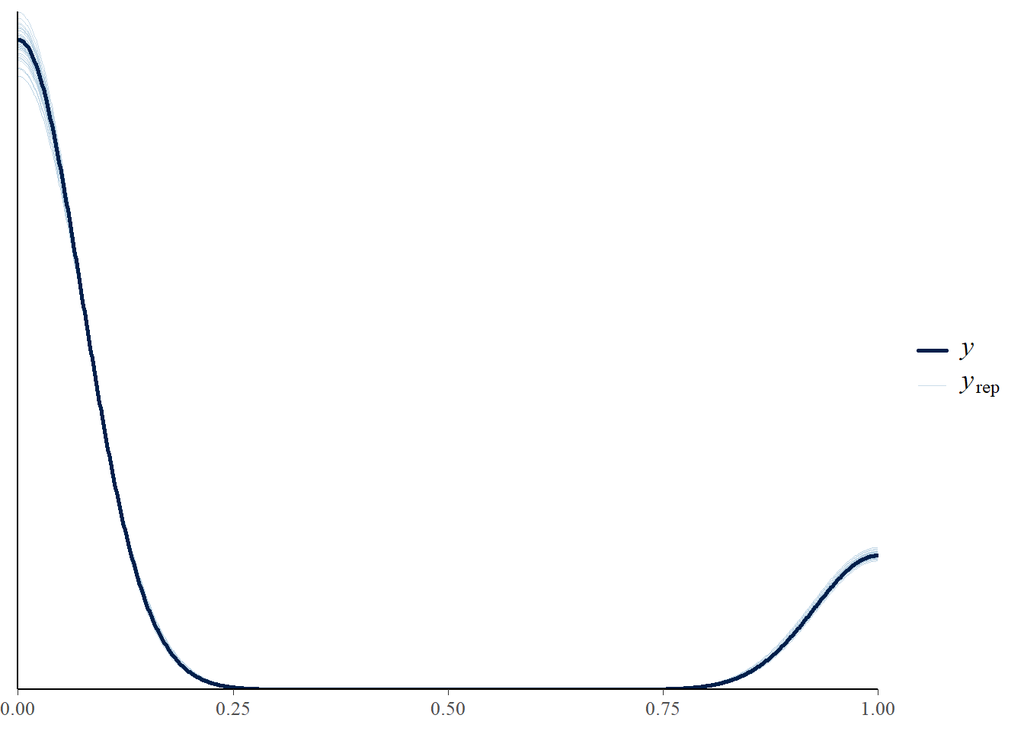

```r
pp_check(bayes_logit)
```

#the ppc confirms that the model is not surprised by the data it was trained on. this, combined with stable convergence diagnostics , ensures that the posterior estimates for the variables are reliable for hypothesis testing.